# ¿Que es la probabilidad?

Lo primero que necesitamos entender es; ¿por que es necesario el concepto de probabilidad en Data Science?

Hagamos una pregunta primero: ¿en que situaciones necesitamos usar la probabilidad? para ello necesitamos hacer otra pregunta que nos induce a eso y este es el motivo de esta primera clase ¿qué es la probabilidad?

La probabilidad siempre se usa en situaciones donde hay **incertidumbre**.

> La incertidumbre tiene que ver básicamente con la toma de decisiones cuando tenemos información incompleta

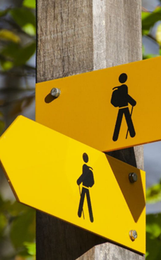

Los juegos de azar son un perfectos ejemplo de esto, ¿por qué? porque tu no puedes predecir el resultado. Esto se debe a que son situaciones que tienen un grado de complejidad en el cual es imposible que tu tengas todas las variables suficientes con todo el conocimiento de datos suficiente como para predecir dependiendo de si tu lanzas los dados de una manera o juegas con las cartas de una manera vas a obtener un cierto resultado.

A eso es a lo que llamamos **incertidumbre**.

Esto nos recuerda una frase muy famosa de Henri Poincaré:

> "El azar no es mas que la medida de nuestra ignorancia. Los fenómenos fortuitos son, por definición, aquellos cuyas leyes o causas simplemente ignoramos. *Henri Poincaré*

Es decir para *Poincaré* la incertidumbre solo es una ilusión y consecuencia precisamente de la falta de información.

### ¿Pero si nosotros tuviéramos la capacidad de tener toda la información necesaria de una situación o de un sistema en particular que queramos?

Así que el azar no es que exista sino que se debe a nuestra incapacidad de tener toda la información suficiente sobre un problema especifico, y pues como estamos limitados de esa manera. Encerramos todas estas situaciones en esa palabra que llamamos **azar** y el objeto de tomar decisiones como **incertidumbre**.

Asi pues como vivimos en una realidad en donde siempre o casi siempre la toma de decisiones implica información incompleta, los matemáticos durante muchos años se propusieron desarrollar un esquema de trabajo para cuantificar la incertidumbre y de ahi nace el area de la **probabilidad** que conocemos como estadística.

Por eso es que en matemáticas decimos que la **probabilidad** se define como:

### Probabilidad

Es el lenguaje y conjunto de herramientas que nos permite cuantificar la **incertidumbre**. Es un area de trabajo, investigación.

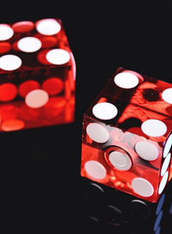

## Axiomas de la probabilidad

Entonces tenemos que pasar a definir cuales son los axiomas de la probabilidad (Es decir todo conjunto de lógica tiene que estar basado en un conjunto de axiomas [conjunto de sentencias o afirmaciones lógicas que no son derivables de algo mas fundamental] que no requieren demostración y simplemente los asumimos como verdad) y así empieza todo en las matemáticas.

### Sucesos

Vamos a definirlos, porque normalmente lo que nos encontramos como definición probabilidad es la división de 2 cantidades.

#### Expliquemos con ejemplo de dados:

Cuando lanzo un dado el resultado del dado son $6$ posibilidades cada una de esas posibilidades representa un suceso, pero los sucesos totales son $6$. Entonces cuando tu me preguntas ¿cuál es la probabilidad de que un dado caiga en 2? Pues el $2$ es una opción de $6$ entonces decimos que la probabilidad es de $\frac 1 6$.  
Pero esto tiene una sutileza que conduce a 2 escuelas de pensamiento en estadística:

- Escuela frecuentista
- Escuela Bayesiana ¿Por qué? Porque si tu defines la probabilidad como $\frac 1 6$ estas diciéndome que estas considerando aunque no lo parezca evidente que todas las caras del dado son igualmente probables, entonces todos los números $1-2-3-4-5-6$ tiene la misma probabilidad de $\frac 1 6$. Y esto nos da la idea a priori que todas las caras son igualmente probables.

También pasa con las monedas, nos enseñan que cuando lanzo una moneda la probabilidad de que caiga cara o que caiga cruz es $\frac 1 2$. Pero ¿que tan cierto es esto? **Depende de como tu interpretas lo que es un suceso o el número de sucesos exitosos** y entonces ¿qué vamos a hacer? Toma un dado o una moneda y lánzalo 10 veces. Y si la probabilidad es como la estamos entiendo en este momento, de los 10 lanzamientos que tu hagas, 5 deberían ser cara y 5 deberían ser cruz.

**Haz el ejercicio y verifica si realmente fueron 5 y 5 los resultados de cara y cruz de una moneda**

#### Resultados de lanzamiento de moneda

| Aguila | Sol |
| --- | --- |
| 4 | 6 |

Como se puede ver no dio un resultado con una probabilidad igual. Aquí es cuando existen 2 escuelas de pensamiento de la probabilidad.

## Frecuentista

Esta escuela nos dice que estos números que nosotros estamos llamando **probabilidades** ya sea de Águila o Sol, son números que solo se alcanzan cuando hacemos infinitos lanzamientos de la moneda o del dado. Es decir si nosotros lanzamos 10, 100, 1000, 1,000,000, infinitas monedas, la proporción entre **el número de lanzamientos exitosos** y **el número de lanzamientos totales** tiende a $\frac 1 2$ es decir se acerca cada vez mas a 0.5. Claro, no hay manera de probar esto y es por esto que lo denominamos como un axioma.

Las probabilidades en realidad, sobre estos posibles sucesos que los llamamos elementales porque son las ocurrencias más básicas de un suceso probabilístico. Una moneda solo tiene $2$ opciones, un dado $6$ opciones y por eso tenemos que diferenciar entre un **suceso elemental** y un **suceso**. $$Probabilidad=P=\frac{N°_{\text{ sucesos exitosos}}} {N°_{\text{ sucesos totales}}}$$

- Suceso elemental

  > "El resultado de lanzar un dado es 4" Es elemental por que el 4 solo sucede de una manera en 6 posibles resultados.
- Mientras que un Suceso en general

  > "El resultado de lanzar un dado es par" No es elemental porque en realidad es la union de varios sucesos que ya definimos elementales. Par quiere decir que puede caer en 2, 4 o 6 y de esta manera es que empezamos a definir conceptos mucho más específicos en probabilidad.

El uso de los **sucesos** y **sucesos elementales** se puede entender mejor a partir de la siguiente imagen

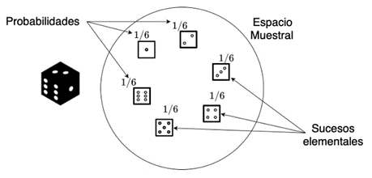

¿Por qué? Porque nosotros cuando tenemos un evento probabilístico, tenemos en realidad algo que llamamos **el espacio muestral**; que es un espacio donde están incluidos todas las posibles ocurrencias de un evento aleatorio.

Por ejemplo el dado tendría un **espacio muestral** de 6 elementos (6 caras en las cuales el dado puede caer) y a cada uno de esos elementos del **espacio muestral** es lo que estamos llamando justamente los **sucesos elementales**, en probabilidad siempre entendemos que todo evento, problema o variable aleatorio/o viene descrito por un **espacio muestral** que contiene elementos donde cada elemento son todas las posibles ocurrencias de ese **problema/evento aleatorio o probabilístico** y en ese sentido también sobre cada uno de los elementos del espacio muestral asignamos un numero que es como una propiedad intrínseca. En el dibujo vemos que cada elemento o cada cara del dado tiene $\frac 1 6$, es decir que cada cara es igualmente probable. Y esto lo estamos asumiendo como un axioma.

Aunque en la vida real las cosas no suceden así, esta representación se hace en el limite teórico infinito, en el que yo hago muchos intentos de una situación particular, así que como es algo abstracto lo asumimos cierto dentro de un esquema que llamamos en matemáticas *"Axiomático*, es decir la probabilidad hace parte de los axiomas y de las propiedades intrínsecas de un problema aleatorio que yo simplemente lo determino asi.

La probabilidad como numero que se asigna a cada posible ocurrencia de un sistema aleatorio tiene varias propiedades y estas propiedades tienen que cumplirse para que tenga sentido.

Las probabilidades como nosotros ya intuimos desde pequeños, digamos con la experiencia día a día que tenemos tiene que ser números que vayan del 0-100% osea o algo es 0% probable o algo es totalmente certero que va a suceder.

### Axiomas de posibilidad:

1. $0\leq P\leq 1$ La probabilidad debe estar entre 0% y 100%
2. $Certeza \rightarrow P=1$
3. $Imposibilidad \rightarrow P=0$
4. Eventos disyuntos $disjuntos\rightarrow P(A\cup B)=P(A)+P(B)$
   - Por ejemplo la probabilidad de que caiga un 2 o un 4, son eventos disyuntos porque es imposible que el dado caiga en ambos al mismo tiempo. Entonces ahí lo que hago es sumar las probabilidades.

## Conclusion

¿Qué es realmente la probabilidad? Se podría decir que;

> es una creencia que tenemos sobre la ocurrencia de eventos elementales. Y esto podría definirse así porque no hay manera de probarlo realmente como dijimos desde la perspectiva frecuentista. Así que la **Probabilidad** se agrega como un axioma en un conjunto de reglas que nos permite cuantificar la incertidumbre.

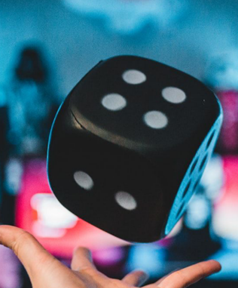

En la siguiente clase vamos a ver como se usa esto en Ciencia de datos y Machine Learning.

## Extras:

- [Escapando de la trampa Bayesiana](https://www.youtube.com/watch?v=D7KKlC0LOyw)
- [Are you Bayesian or Frequentist](https://www.youtube.com/watch?v=D7KKlC0LOyw)